# Week 2 lab 10

# Sprints data, revisited

Below we read in a data frame `sprint.w.df` containing the top women’s times in the 100m sprint, as seen in previous labs. We also define a function `factor.to.numeric()` that was used in Lab 8, to convert the Wind column to numeric values. In what follows, use `dplyr` and pipes to answer the following questions on `sprint.w.df`.

```r
sprint.w.df = read.table(
  file="http://www.stat.cmu.edu/~ryantibs/statcomp/data/sprint.w.dat",
  sep="\t", header=TRUE, quote="", stringsAsFactors=TRUE)

factor.to.numeric = Vectorize(function(x) {
  x = strsplit(as.character(x), split = ",")[[1]]
  ifelse(length(x) > 1,
         as.numeric(paste(x, collapse=".")),
         as.numeric(x))
})
```

- **3a.** Convert the Wind column to numeric using `factor.to.numeric()`. Hint: use `mutate_at()`, and reassign `sprint.w.df` to be the output.

```r
sprint.w.df$Wind <-sprint.w.df$Wind%>%
  factor.to.numeric()
```

```r
filter(sprint.w.df, Wind >0)%>%
  lm(data =., Time~Wind)
```

```
##
## Call:
## lm(formula = Time ~ Wind, data = .)
##
## Coefficients:
## (Intercept)         Wind
##      10.998       -0.006
```

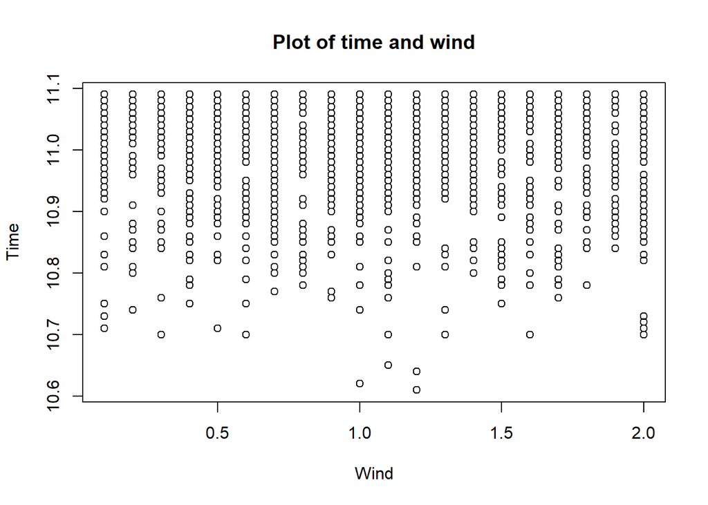

```r
filter(sprint.w.df, Wind >0)%>%
  plot(data = ., Time~Wind, xlab = "Wind",ylab = "Time", main = "Plot of time and wind")
```

- **3d.** Reorder the rows in terms of increasing Wind, and then display only the women who ran at most 10.7 seconds. Hint: do this with one single flow of pipe commands; use `arrange()`, `filter()`.

```r
arrange(sprint.w.df,Wind)%>%
  filter(.,Time < 10.7)
```

```
##   Rank  Time Wind                     Name Country Birthdate
## 1    6 10.67 -0.1          Carmelita Jeter     USA  24.11.79
## 2    1 10.49  0.0 Florence Griffith-Joyner     USA  21.12.59
## 3    1 10.60  0.0             Zhanna Block     UKR  06.07.72
## 4    3 10.62  1.0 Florence Griffith-Joyner     USA  21.12.59
## 5    5 10.65  1.1             Marion Jones     USA  12.10.75
## 6    2 10.61  1.2 Florence Griffith-Joyner     USA  21.12.59
## 7    4 10.64  1.2          Carmelita Jeter     USA  24.11.79
##                  City       Date
## 1 Thessalon&iacute;ki 13.09.2009
## 2        Indianapolis 16.07.1988
## 3                Kiev 12.06.1997
## 4               Seoul 24.09.1988
## 5        Johannesburg 12.09.1998
## 6        Indianapolis 17.07.1988
## 7            Shanghai 20.09.2009
```

- **3e.** Now reorder the rows in terms of increasing Time, and *then* increasing Wind, and again display only the women who ran at most 10.7 seconds, but only display the Time, Wind, Name, and Date columns. Hint: a single flow of pipe commands will do; note that `arrange()` can take multiple columns that you want to sort by, and the order you pass them specifies the priority.

```r
arrange(sprint.w.df,Time,Wind)%>%
  filter(.,Time < 10.7)%>%
  .[,c(2,3,4,8)]
```

```
##    Time Wind                     Name       Date
## 1 10.49  0.0 Florence Griffith-Joyner 16.07.1988
## 2 10.60  0.0             Zhanna Block 12.06.1997
## 3 10.61  1.2 Florence Griffith-Joyner 17.07.1988
## 4 10.62  1.0 Florence Griffith-Joyner 24.09.1988
## 5 10.64  1.2          Carmelita Jeter 20.09.2009
## 6 10.65  1.1             Marion Jones 12.09.1998
## 7 10.67 -0.1          Carmelita Jeter 13.09.2009
```

# Prostate cancer data, revisited

Below we read in a data frame `pros.df` containing measurements on men with prostate cancer, as seen in previous labs. As before, in what follows, use `dplyr` and pipes to answer the following questions on `pros.df`.

```r
pros.df =
  read.table("http://www.stat.cmu.edu/~ryantibs/statcomp/data/pros.dat")
```

- **4a.** Among the men whose lcp value is equal to the minimum value, report the lowest and highest lpsa score.

```r
filter(pros.df, lcp == min(lcp))%>%
  max(.$lpsa)
```

```
## [1] 80
```

```r
filter(pros.df, lcp == min(lcp))%>%
  min(.$lpsa)
```

```
## [1] -1.386294
```

- **4b.** Order the rows by decreasing age, then decreasing lpsa score, and display the rows from men who are older than 70, but only the age, lpsa, lcavol, and lweight columns.

```r
arrange(pros.df,desc(age),desc(lpsa))%>%
  filter(.,age >70)%>%
  .[c(1,2,3,9)]
```

```
##        lcavol  lweight age       lpsa
## 47  2.7278528 3.995445  79  2.5687881
## 78  2.5376572 4.354784  78  3.4355988
## 83  2.6130067 3.888754  77  3.5652984
## 72  1.1600209 3.341093  77  3.0373539
## 90  1.5623463 3.695110  76  3.9936030
## 3  -0.5108256 2.691243  74 -0.1625189
## 61  0.4574248 4.524502  73  2.8419982
## 37  1.4231083 3.657131  73  2.1575593
## 77  2.0108950 4.433789  72  3.3928291
## 70  1.1939225 4.780383  72  2.9729753
## 68  2.1983351 4.050915  72  2.9626924
## 63  2.7757089 3.524889  72  2.8535925
## 33  1.2753628 3.037354  71  2.0082140
```

```r
filter(pros.df, lcp > min(lcp))%>%
  lm(data = .,lpsa~lcavol)
```

```
##
## Call:
## lm(formula = lpsa ~ lcavol, data = .)
##
## Coefficients:
## (Intercept)       lcavol
##      1.6696       0.6726
```

- **4d.** Extend your code in the last part, still just using a single flow of pipe commands in total, to extract the p-values associated with each of the coefficients in the fitted model.

```r
filter(pros.df, lcp > min(lcp))%>%
  lm(data = .,lpsa~lcavol)%>%
  summary(.)%>%
  .$coefficients%>%
  .[,4]
```

```
##  (Intercept)       lcavol
## 2.031625e-08 7.643369e-07
```